### Digital Politics, Social Media, and Misinformation

### L32 3381

#### Class information

##### Lecture

Monday and Wednesday  
10:00am – 11:20am  
Zoom link: See canvas

#### Instructor Information

Jacob M. Montgomery, Ph.D.  
Associate Professor, Department of Political Science  
**Office**: Seigle 285 (hahahah no I will be at the zoom link on Canvas and not in my office)  
**E-mail**: jacob.montgomery@wustl.edu  
**Office Hours**: Wed. 1:30-3:30 and by appointment

#### Textbooks/Readings

Almost all of the required readings (and many of the optional readings) will be linked to from this document or provided on Canvas. Some links to academic papers may only be accessible when you are [using a VPN](https://it.wustl.edu/items/connect/) due to firewalls.

The required textbook is:

Social Media and Democracy: The State of the Field and Prospects for Reform. Edited by Nathaniel Persily and Joshua Tucker.

### Course description

The transformation of the media environment in the past decade has had a dramatic effect on the political process both here in the United States and around the world. In this class, we will survey recent work in the social sciences examining the role of digital technologies and social media in our politics, ranging from the good (e.g., more direct influence on media narratives) to the bad (e.g., the spread of misinformation).

#### Learning objectives

By the end of this course, you should be able to:

1. Understand how social connections and social media can be used to empower collective action.
2. Articulate the tensions between the need for platforms to regulate harmful speech and behavior and the value of allowing unfiltered free expression.
3. Understand how the technology of social media interacts with broader social and political forces in the United States and abroad.
4. Explain the basic psychological mechanisms that makes individuals susceptible to misinformation and how those mechanisms intersect with new communication technology.
5. Analytically apply these concepts to better understand how you personally interact with digital media and how it is shaping your own political world.
6. Critically evaluate claims (and the evidence used to support those claims) about the effects of social media on democracy and politics.

#### Expectations and structure

1. This class was specifically designed for the Zoom era of online learning. While this format is crappy for many things, it does facilitate bringing outside experts into the class. A centerpiece of the course, therefore, will be 16 visitors who will bring their expertise and experience to inform our discussion.
2. This is a fairly reading-intensive class for undergraduates. Each class session will include (approximately) two academic papers/book chapters as well as some related news articles/podcasts/etc.[^1] Note that these will be real-world academic papers reflecting the cutting edge of research on this topic. This is me saying that **some of the readings will be very hard**. I do *not* expect you to understand all of the technical terms/discussions, but do expect you to understand: (a) the major claims made by the authors, (b) the evidence used to support those claims, and (c) how the paper fits into the broader themes of the class. I also expect you to bring questions about the mathy gobbldygook you don’t understand so we can talk through it during class. I anticipate that this will take you 6-9 hours of study/prep time *per week*.
3. This class is designed to be discussion based and interactive. That is **so** much harder to do on Zoom than in person, and I get it. But I really need you to put in the effort, and to ensure that I will also ask you to do some “reactions” in advance of our class meeting. I will do my best to make things fun and engaging, but you’ve got to do your part by showing up prepared. If we all do our job, this will be awesome.
4. While we will not be doing statistical analyses in this class, we will be reading many papers with statistics. PS 363 (or equivalent) is not required for this class, but it sure would be helpful. But you should anticipate that we will at least talk through the statistical results as a class for many of the readings. I do not expect you to undestand them without assistance.

#### Some help getting started with the reading

Academic articles can be confusing, especially papers with lot’s of statistics you don’t understand. If you are struggling, look at some guides such as “[How to Read Political Science: A Guide in Four Steps](https://www.ameliahoovergreen.com/uploads/9/3/0/9/93091546/howtoread.pdf)” by Amanda Hoover Green or [“How to Read a (Quantitative) Journal Article](https://www.asanet.org/sites/default/files/savvy/introtosociology/Documents/MethodsDocuments/KrippnerReadingQuantArticle.html)” by Greta Krippner.[^2]

Here are a set of questions to think about as you read to help you get ready for class:

1. What claim or argument are the authors trying to convince you is true/not true?
2. Why would we ever doubt that this claim is true? Who are they arguing with? Why don’t we know this already?
3. What is the mechanism they are suggesting? What is the social, technical, or psychological process that leads to their predicted outcome?
4. What is the evidence they provide in support of their claim? Is it an experment? A survey? Did they scrape the Internet?
5. Does this argument/finding support of contradict other readings? What connections can you draw between this article and the others?
6. Were you convinced by this article that the claim is true?

#### Assistants to instructor

Dominique Lockett is assisting me in teaching this class. She is a graduate student concentrating in computational social science. Her primary role will be to make sure the class runs smoothly, take care of basic grading tasks, and be a resource for further questions. She will be working closely in conjunction with Professor Montgomery on all issues of grading. I encourage you to get to know the assistant and remind you to always be respectful and patient. I would prefer you to be rude to me than to my assistant.

##### Graduate ATIs (office hours and link)

Dominique Lockett  
Email: dlockett@wustl.edu  
Office hours: Mondays at 11:30am  
Zoom link on Canvas

#### Learning in the age of Covid-19

Some of you are in St. Louis and some of you are not. Some of you have easy access to library resources and some of you have very little. Some of you may be healthy, and some of you may be ill or have experienced illness in your family. This class is especially designed for this environment and I will try and be understanding and flexible. I ask you that you return the favor as I deal with learning new EdTech, balance my work and trying to help the first-grader, and you get the idea. But there are 40 of you and I do have to have some policies in place just to keep the trains running and myself sane. Read the rules for the class carefully so you understand where you have flexibility (and where you do not) and come to me as early as possible if you are having problems that may make meeting these targets difficult.

#### Requirements and Evaluation

Grading in this class will be based on the components described below. *Late work will not be accepted without prior permission*. With that said, the course is designed to be flexible to accomodate varying student needs in these difficult times.

| If you get | you get an |
| --- | --- |
| $\ge$ 93 | A |
| $\ge$ 90 | A- |
| $\ge$ 87 | B+ |
| $\ge$ 83 | B |
| $\ge$ 80 | B- |
| $\ge$ 77 | C+ |
| $\ge$ 73 | C |
| $\ge$ 70 | C- |
| $\ge$ 67 | D+ |
| $\ge$ 63 | D |
| $\ge$ 60 | D- |
| $<$ 60 | Fail |

##### In-class participation (10%)

Assessment of class contribution will be based on participation in discussion of readings. Class contributions will be assessed based on quality, not quantity. Quality participation includes substance, demonstrated knowledge of reading material, professionalism, and respect to other students. If you don’t talk for a large number of classes, that will inevitably lead to a failing grade for this component. But if you are a shy person, remember that participation grades will be based on the quality of your participation and not the quantity. Take the opportunity to think about he materials in advance and plan something to say.

It is perfectly acceptable to disagree with each other, and I especially encourage you to disagree with me. But always try and explain the evidence you are using to support your claim. With that said, uncivil or disrespectful communication will not be tolerated.

We will drop your lowest grades for three (3) class sessions. However, I strongly encourage you to attend each class session.

##### Pre-class assignments (10%)

To help keep the class interesting, for most sessions I will ask you to complete small tasks in advance of each class. Usually this will be to add a new question or idea to a list for the class to cover when it meets. But it may involve making a meme related to our topic of discussion, finding examples of social media posts that reflect the topic, playing a game related to the topic, etc.

We will drop the grades for the four (4) lowest grades for pre-class assignments.

##### Discussion co-leader (15%)

Three times during the semester you will serve as a co-leader of the class along with me. This means that you will need to be especially attentive to the readings, help me manage the chat, give your best opinions when I ask questions, and generally help make the class run smoother. For classes with visitors, you will also be the point person for collecting questions from the class (in advance and from the chat box) to ask our guests.

##### Going deeper (20% - 10% each)

Twice during the semester you will take on one of the additional assignments and write a response paper. Usually this will be two papers or two book chapters. Often there will be a theme or an inherent disagreement in the readings.[^3] These extra readings should be done *in addition* to the main readings for that week and may not be for a class session here you are a discussion co-leader. These response papers must be turned in to me via Slack by 10pm the day before the class discussion. You will lose 10% of your grade for every day it is late after that.

Your assignment will be to write a short response paper (no more than 1000 words, excluding ciations) in double-spaced 12-point font. You can use endnotes or footnotes of any kind, as long as you cite.

This should be an analytical response, where you take a position and support your claim using specific evidence from the readings (or from other sources). You might, for instance, discuss why you found the evidence in one paper more convincing than another. You might apply the theory described to a new example or explain why it won’t hold up for some other social media platform.[^4] It can be anything you want, so long as you make an argument and support it with evidence.

No more than one page of this response should *summarize* the papers or it will be returned for revision without a grade. Time permitting, you will also be asked to provide a short discussion (about 5 minutes) explaining the readings as well as your response during class.

##### Magnify project/Respone paper (15%)

In Class 4 I will introduce you to the *Magnify* social media platform designed to help groups use the power of social media to foster civic engagement. You will choose choose a project and use Magnify (and/or other social media) to engage in civic activity and recruit your peers to your cause. Attend a city council meeting, support a candidate for St. Louis Mayor, raise money for a cause, or get that ugly pothole filled on your street. You must achieve “Wizard” status by the end of the project period (10%). You must also provide me with a two page (no more than 600 words) narrative describing your project and how the strategies you used to foster engagement related to the concepts we have covered in class (5%).[^5]

In addition:

- 1% will be given to the student with the most points on magnify at the end of the semester. (The start of class on May 3)
- I will draw, at random, from the top 50% of students for magnify points who will receive a 1% bonus on their final grade.

##### Public Editor project/Response paper (10%)

For this project, *you* are going to try and be a content moderator and evaluate the veracity of news content.

- Go to https://www.publiceditor.io/ and register.
- Complete at least five tasks as a specialist for under four different specialist categories. You may want to do more to help you find a good idea for your response paper.
- Write a two page (no more than 600 words) response paper to your experience as a coder. Explain how this experience relates to the readings (be sure to cite!).

#### Research design memo (20%)

Imagine you work at a social media company and have been asked to propose a change to the policies to improve democratic outcomes. Your assignment is to write a 1,200-1,500 word (excluding references) memo that achieves the following goals:

1. It should articulate a *problem*. What ar we trying to fix?
2. It should cite the relevant literature (from the class reading and beyond) explaining what effect the proposed change should have on specific outcomes *and why*. Convince your boss that this might work based on previous research.
3. It should explain how the change will be evaluated. That is, what research design will we use to ensure that the change has the intended effect?

A couple of things to think about if you are struggling:

- Articulate a problem that you care about and experience/observe online. Stick to political science issues to the extent possible but it’s not a hard rule. Then think about how the ideas we have discussed in this class point towards a *potential* solution.
- Social science research focuses on very few platforms because of data limitations. But here you can imagine you are an *insider*. Just assume you have access to all the data you want for any platform you want.
- This doesn’t have to be very original. Try and think what would theory XXX say about platform YYYY. Or how intervention ZZZ could be modified to address problem QQQ.
- Model the research design on the papers we have read for the class. When in doubt, stick to an experiment (they are easiest to describe and justify).
- Be sure to run your idea by me early in the writing process! I have office hours for a reason.

We will discuss a selection of your ideas as a class in our final session.

##### Extra credit

**No adjustments will be made to final grades under any circumstances.** Students will have the opportunity to earn extra credit over the course of the semester to provide an extra cushion in case of a malfunctioning computer, or unusual anxiety during due to the opening of the Chamber of Secrets, an attack by rogue dementors, the sudden death of the Headmaster, or the return of You Know Who.

- As noted above, there are two opportunities for extra credit through the Magnify project.
- Students can also increase their final grade 1% by completing their official online course evaluations for both Professor Montgomery and assistants to the instructor for their lab.

### Class policies

#### Class organization/software

This class will be taught exclusively online via Zoom and will be synchronous. All class sessions will be recorded and available via Canvas. But this is a discussion based class and your attendance and participation are part of your grade. If you are in a location where you are comfortable turning on your camera, I encourage you to do so. This will make the class more enjoyable for everyone. Please also be sure that you find a location with a reliable Internet connection.

#### Class communications

While students are free to email me, my inbox is a trainwreck. All class communications will take place over Slack. You must sign up for Slack and join the (digitalpoliti-4x26202.slack.com) workspace. You should only email me if it is something very confidential that you do not trust to Slack’s privacy policies. If you have questions about assignments, I particularly encourage you to post it to #class-questions since it is very likely that other students will have the same question and it is convenient for me to answer where everyone can see.

All class discussions will also take place over slack. For many classes you will be expected to post questions or examples to a specific channel. You may also be asked to contribute to or help edit a post.

#### Grade Appeals

If you wish to appeal the grading of an assignment, you must inform either me or an assistant to the instructor within 72 hours of the time when the graded assignment is returned to the class. Assignments returned on Thursday or Friday must be returned by Noon on the following Monday. You must provide the orginal assignment as well as an explanation of why your assignment deserves additional credit.

#### Stay on target

A great deal of research has shown than student learning is significantly harmed when students are multi-tasking. I know it’s hard, but please try and focus on the class during class time and refrain from shopping, watching sports, finding new cat videos, perfecting the latest TikTok dance, chatting, reading news, creating shady online disinformation operations, and other young people activities.

#### Academic Honesty

Cheating and plagiarism will not be tolerated. I strongly encourage you to review the University’s policies regarding academic honesty, which you can read at: http://www.wustl.edu/policies/undergraduate-academic-integrity.html.

In general, if you have any question, please feel free to ask Professor Montgomery. It is much easier to answer questions than to fill out all fo the paperwork for an academic integrity violation.

- *Do NOT copy and paste content unless you are citing and include quotations.
- When in doubt, include the appropriate citattion.
- It woudl be *much* better to get a zero on an assignment than to violate these rules. Don’t do it.

All cases of cheating or plagiarism will be referred to Washington University’s Committee on Academic Integrity. If the Committee on Academic Integrity finds a student guilty of cheating, then the penalty will be (without exception) automatic failure of the course.

#### Students with disabilities

Students with disabilities enrolled in this course who may need disability-related classroom accommodations are encouraged to make an appointment to see me before the end of the second week of the semester. All conversations will remain confidential.

#### Religious observances

Some students may wish to take part in religious observances that occur during this semester. If you have a religious observance that conflicts with your participation in the course, please meet with me *before the end of the second week of the semester* to discuss accommodations.

#### Accommodations based upon sexual assault

The University is committed to offering reasonable academic accommodations to students who are victims of sexual assault. Students are eligible for accommodation regardless of whether they seek criminal or disciplinary action. Depending on the specific nature of the allegation, such measures may include but are not limited to: implementation of a no-contact order, course/classroom assignment changes, and other academic support services and accommodations. If you need to request such accommodations, please direct your request to Kim Webb (kim_webb@wustl.edu), Director of the Relationship and Sexual Violence Prevention Center. Ms. Webb is a confidential resource; however, requests for accommodations will be shared with the appropriate University administration and faculty. The University will maintain as confidential any accommodations or protective measures provided to an individual student so long as it does not impair the ability to provide such measures.

If a student comes to me to discuss or disclose an instance of sexual assault, sex discrimination, sexual harassment, dating violence, domestic violence or stalking, or if I otherwise observe or become aware of such an allegation, I will keep the information as private as I can, but as a faculty member of Washington University, **I am required to immediately report it to my Department Chair or Dean or directly to the University’s Title IX Coordinator**. If you would like to speak with the Title IX Coordinator directly, Ms. Jessica Kennedy can be reached at (314) 935-3118, jwkennedy@wustl.edu, or by visiting her office in the Women’s Building. Additionally, you can report incidents or complaints to Tamara King, Associate Dean for Students and Director of Student Conduct, or by contacting WUPD at (314) 935-5555 or your local law enforcement agency.

You can also speak confidentially and learn more about available resources at the Relationship and Sexual Violence Prevention Center by calling (314) 935-8761.

## Schedule

**NOTE:** Below is a schedule of assignments. **You should check Canvas before each class session for any pre-class assignments.** Students are responsible for checking Canvas in advance of each class session as the tasks listed below are preliminary and may be adjusted based on student feedback.

[video not shown]

1. January 25: Introductions and dramatic reading of the syllabus
   - **Required Readings**
     - [How to use social media data for political science research](https://sk.sagepub.com/reference/the-sage-handbook-of-research-methods-in-political-science-and-ir/i3919.xml). Pablo Barberá and Zachary C. Steinert-Threlkeld. *The SAGE Handbook of Research Methods in Political Science and International Relations*.
     - Read this syllabus right here that you are reading right now.
   - **Pre-class assignment**:
     - Join the course Slack workspace using the link on Canvas.
     - Complete the class survey linked to on Canvas.

[figure not shown]

[figure not shown]

3. February 1: Social media for social good
   - **Required Readings**
     - [A 61-million-person experiment in social influence and political mobilization](https://www.nature.com/articles/nature11421). 2012. Robert M. Bond, Christopher J. Fariss, Jason J. Jones, Adam D. I. Kramer, Cameron Marlow, Jaime E. Settle, and James H. Fowler. *Nature*.
     - [Social Pressure on Social Media: Using Facebook Status Updates to Increase Voter Turnout](https://academic.oup.com/joc/article-abstract/66/4/542/4082384). 2016. Katherine Haenschen. *Journal of Communication*.
   - **Going deeper**:
     - [Experimental evidence of massive-scale emotional contagion through social networks](https://www.pnas.org/content/111/24/8788.short). 2014. Adam D. I. Kramer, Jamie E. Guillory, and Jeffrey T. Hancock. *Proceedings of the National Academy of Sciences*.
     - [Facebook Tinkers with users’ Emotions in news Feed Experiment, Stirring Outcry](http://cs110.wellesley.edu/~cs110/assignments/a03/Facebook-Privacy.pdf). 2014. Vindu Goel. *New York Times*.
     - [Informed consent and the Facebook emotional manipulation study](https://journals.sagepub.com/doi/full/10.1177/1747016115599568). 2015. Catherine Flick. *Research Ethics*.
   - **Pre-class assignment**:
     - Find an example where you used social media to encourage civic engagement or someone encouraged you to participate. If you feel comfortable, post it to the slack channel for this class and explain whether or not it was effective and why. Otherwise, simply describe the post/effort.
     - Add a discussion question to the pinned Slack post for this class. Be sure to have your name next to your question to receive credit.

[figure not shown]

4. February 3: **Dr. Betsy Sinclair**. Professor of Political Science. Washington University in St. Louis. Co-founder of Magnify Your Voice.
   - **Required Readings/Watching**
     - *The Social Citizen: Peer Networks and Political Behavior*. 2012. Betsy Sinclair. (Chapters 1 & 3)
     - Watch [this video on Magnify](https://www.youtube.com/watch?v=62QGJ9WTmiM)
   - **Going deeper**:
     - *The Social Citizen: Peer Networks and Political Behavior*. 2012. Betsy Sinclair. (Chapters 2 & 4)
   - **Pre-class assignment**:
     - Follow the instructions posted on Canvas to create your own Magnify account and look through the kinds of projects other users have started.
     - Think of at least two civic activities you would like to get involved in. Be ready to ask Prof. Sinclair about your favorite idea.
     - Add a to the list of questions for our guest to the pinned Slack post for this class. Be sure to have your name next to your question to receive credit. You are specifically looking for ideas about how you can connect ideas from your readings to strategies you will use on magnify (e.g., comparing responsivness of close social ties versus distant social ties).
   - **Project note**: This marks the start of the Magnify project (see description above). The project is due March 9. However, the extra credit contest will continue until the end of the semester.

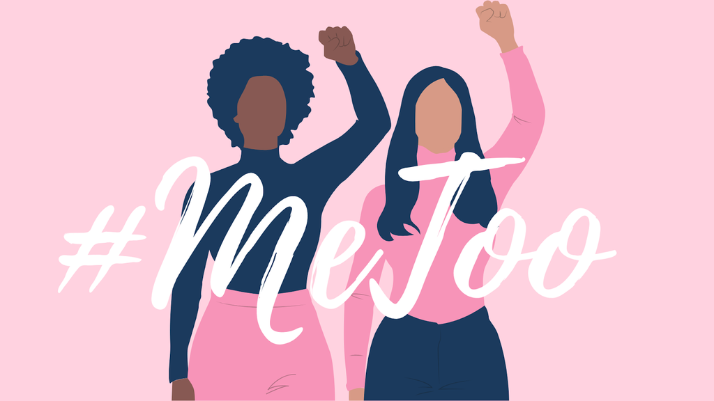

5. February 8: Hashtag activism
   - **Required Readings/Watching**
     - *#HashtagActivism: Networks of Race and Gender Justice*. 2020. Sarah J. Jackson, Moya Bailey, and Brooke Foucaul Welles. (Forward by Genie Lauren and Chapter 1)
     - [*The Effects of Social Movements: Evidence from #MeToo*](https://papers.ssrn.com/sol3/papers.cfm?abstract_id=3496903). 2020. Roee Levy and Martin Mattsson.
     - [Check out the virtual timeline of twitter activism](https://hashtagactivismbook.com/timeline/).
   - **Going deeper**:
     - *#HashtagActivism: Networks of Race and Gender Justice*. 2020. Sarah J. Jackson, Moya Bailey, and Brooke Foucaul Welles. (Chapters 2 & 3)
     - *#HashtagActivism: Networks of Race and Gender Justice*. 2020. Sarah J. Jackson, Moya Bailey, and Brooke Foucaul Welles. (Chapters 4 & 5)
     - *#HashtagActivism: Networks of Race and Gender Justice*. 2020. Sarah J. Jackson, Moya Bailey, and Brooke Foucaul Welles. (Chapters 6). (Should be paired with next article.)
     - [White folks’ work: digital allyship praxis in the #BlackLivesMatter movement](https://www.tandfonline.com/doi/full/10.1080/14742837.2019.1603104). 2019. Meredith D. Clark. *Social Movement Studies*. (Should be paired with the previous article).
   - **Pre-class assignment**:
     - Add a discussion question to the pinned Slack post for this class. Be sure to have your name next to your question to receive credit.

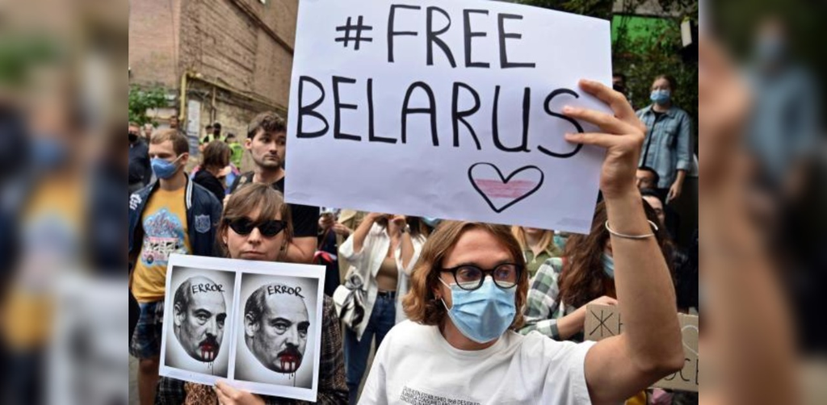

6. February 10: Social media and protests/social movements abroad
   - **Required Readings/Watching**
     - [Social Networks and Protest Participation: Evidence from 130 Million Twitter Users](https://onlinelibrary.wiley.com/doi/full/10.1111/ajps.12436). 2019. Jennifer M. Larson, Jonathan Nagler, Jonathan Ronen, and Joshua A. Tucker. *American Journal of Political Science*.
     - [Opening Closed Regimes: What Was the Role of Social Media During the Arab Spring?](https://deepblue.lib.umich.edu/bitstream/handle/2027.42/117568/2011_Howard-DuffyFreelon-Hussain-Mari-Mazaid_PITPI.pdf?sequence=1). 2011. Philip Howard, Aiden Duffy, Deen Freelon, Muzammmil Hussain, Will Mari, and Marwa Mazaid.
     - [Video contradicts Morocco’s justification of a brutal beating in Western Sahara](https://www.washingtonpost.com/politics/2020/03/12/video-contradicts-moroccos-justification-brutal-beating-western-sahara/). 2020. Sarah Cahlan and Elyse Samuels. *Washington Post*
     - [This social media app is driving the Belarus protests](https://www.csmonitor.com/World/Europe/2020/0821/This-social-media-app-is-driving-the-Belarus-protests). 2020. Daria Litvinova. Asociated Press.
   - **Going deeper**:
     - [(a) Protests and Demonstrations in Northern Ireland, with Dr. Paul Reilly](https://socialmediaandpolitics.simplecast.com/episodes/69-protests-and-demonstrations-in-f0110c86). Social Media and Politics Podcast. January 13th, 2019.
     - [(a) Tweeting for peace? Twitter and the Ardoyne parade dispute in Belfast, July 2014](https://firstmonday.org/ojs/index.php/fm/article/view/6996). 2016. Paul Reilly. *First Monday*.
     - [(b) Social media use and university students’ participation in a large-scale protest campaign: The case of Hong Kong’s Umbrella Movement](https://www.sciencedirect.com/science/article/pii/S0736585316301174). 2017. Francis L.F.Lee, Hsuan-Ting Chen, and Michael Chan. *Telematics and Informatics*.
     - [(b) Media Use and Protest Mobilization: A Case Study of Umbrella Movement Within Hong Kong Schools](https://journals.sagepub.com/doi/full/10.1177/2056305118763350). 2018. Donna SC Chu. *Social Media + Society*.
   - **Pre-class assignment**:
     - Add a discussion question to the pinned Slack post for this class. Be sure to have your name next to your question to receive credit.

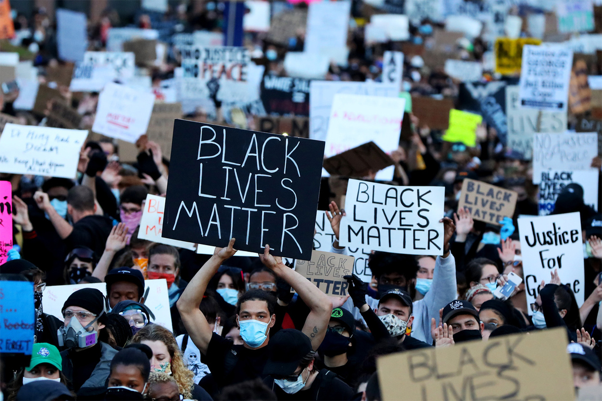

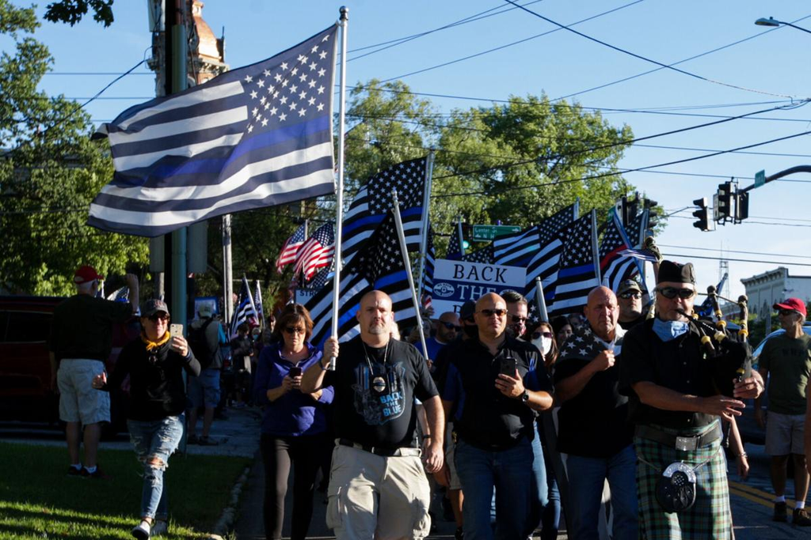

7. February 15: Online Activism. **Dr. Deen Freelon**. Associate Professor, Hussman School of Journalism and Media, UNC-Chapel Hill.
   - **Required Readings**
     - [False equivalencies: Online activism from left to right](http://dfreelon.org/publications/2020_False_equivalencies_Online_activism_from_left_to_right.pdf). 2020. Deen Freelon, Alice Marwick, and Daniel Kreiss. *Science*.
     - [Quantifying the power and consequences of social media protest](https://journals.sagepub.com/doi/abs/10.1177/1461444816676646). 2016. Deen Freelon, Charlton McIlwain, and Meredith Clark. *New Media & Society*.
   - **Going deeper**:
     - [(a) Computational Research in the Post-API Age](https://www.tandfonline.com/doi/full/10.1080/10584609.2018.1477506). 2018. Deen Freelon. *Political Communication*.
     - [(a) Facebook needs to share more with researchers](https://www.nature.com/articles/d41586-020-00828-5). 2020. Simon Hegelich. *Nature*.
     - [(b) Beyond the Hashtags: #Ferguson, #Blacklivesmatter, and the online struggle for offline justice](http://dfreelon.org/publications/2016_Beyond_the_hashtags_Ferguson_Blacklivesmatter_and_the_online_struggle_for_offline_justice.pdf) 2016. Deen Freelon, Charlton McIlwain, and Meredith Clark.
     - [(c) Hijacking #myNYPD: Social Media Dissent and Networked Counterpublics](https://onlinelibrary.wiley.com/doi/abs/10.1111/jcom.12185). 2015. Sarah J. Jackson and Brooke Foucault Welles. *Journal of Communication*.
     - [(c) Gay men have taken over the Proud Boys Twitter hashtag](https://www.cnn.com/2020/10/04/us/proud-boys-twitter-hashtag-gay-men-trnd/index.html). 2020. Alaa Elassar. CNN.com
   - **Pre-class assignment**:
     - Add a to the list of questions for our guest to the pinned Slack post for this class. Be sure to have your name next to your question to receive credit.

[figure not shown]

8. Feb 17: Media bubbles and polarization. **Dr. Pablo Barberá**. Associate Professor, Department of Political Science and International relations, University of Sourthern California. Research Scientist, Facebook.
   - **Required Readings**
     - [Do our platforms bring us together or push us apart?](https://www.youtube.com/watch?v=sfL8PfXV2RY&feature=youtu.be). 2020. Christopher Bail. (Video)
     - Social Media, Echo Chambers, and Political Polarization. 2020. Pablo Barberá. *Social Media and Democracy*. (Required text)
     - [Shared Partisanship Dramatically Increases Social Tie Formation in a Twitter Field Experiment](https://psyarxiv.com/ykh5t/). 2021. Mohsen Mosleh, Cameron Martel, Dean Eckles, and David G. Rand.
     - [(Almost) Everything in Moderation: New Evidence on Americans’ Online Media Diets](https://andyguess.com/publication/guess-2020-everything/). 2021. Andrew Guess. *American Journal of Political Science*. (Focus on introduction and discussion)
   - **Going deeper**:
     - [(a) Exposure to ideologically diverse news and opinion on Facebook](https://science.sciencemag.org/content/sci/348/6239/1130.full.pdf). 2015. Eytan Bakshy, Solomon Messing, and Lada A. Adamic. *Science.*
     - [(a) How Many People Live in Political Bubbles on Social Media? Evidence From Linked Survey and Twitter Data](https://journals.sagepub.com/doi/pdf/10.1177/2158244019832705). 2019. Gregory Eady, Jonathan Nagler, Andy Guess, Jan Zilinsky, and Joshua A. Tucker. *SAGE Open*.
     - [(b) Frenemies: How Social Media Polarizes America](https://www.amazon.com/Frenemies-Social-Media-Polarizes-America/dp/1108472532). 2018. Jaime E. Settle. (Chapters 1-3)
   - **Pre-class assignment**:
     - Add a discussion question to the pinned Slack post for this class. Be sure to have your name next to your question to receive credit.
     - Evaluate your social media feed of interest. Evaluate how often you come across content from political opposites? How would you measure it and what does it mean? Be ready to answer these questions in class.

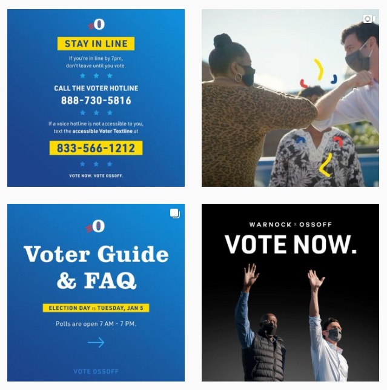

9. Feb 22: Elites and campaigns: **Elias Duncan**. Digital Director, Ossof for Senate.
   - **Required Readings**
     - Mediated Democracy: Politics, The News, and Citizenship in the 21st Century. 2021. Machael W. Wagner and Mallory R. Perryman. (Chapters 1 & 5 available on Canvas).
     - Who Leads? Who Follows? Measuring Issue Attention and Agenda Setting by Legislators and the Mass Public Using Social Media Data. 2019. Pablo Barberá et al. *American Political Science Review*.
   - **Going deeper**:
     - [(a) Twitter use in election campaigns: A systematic literature review](https://www.tandfonline.com/doi/abs/10.1080/19331681.2015.1132401). 2016. Andreas Jungherr. *Journal of Information Technology & Politics*.
     - [(a) Online Engagement and Digital Campaigning for Pete Buttigieg, with Stefan Smith](https://socialmediaandpolitics.simplecast.com/episodes/online-engagement-digital-campaigning-for-pete-buttigieg-with-stefan-smith-vJlgL5ai). Social Media and Politics podcast.
     - [(b) Personalization, gender, and social media: gubernatorial candidates’ social media strategies](https://www.tandfonline.com/doi/abs/10.1080/1369118X.2016.1167228?journalCode=rics20). Shannon C. McGregor, Regina G. Lawrence, and Arielle Cardona. *Information, Communication & Society*.
     - [(b) Towards Measuring Adversarial Twitter Interactions against Candidates in the US Midterm Elections](https://ojs.aaai.org//index.php/ICWSM/article/view/7298). 2020. Yiqing Hua, Thomas Ristenpart, and Mor Naaman. *Proceedings of the International AAAI Conference on Web and Social Media*.

[figure not shown]

10. Feb 24: New media and old media. **David Ingram**. Technology Reporter, NBC News.
    - **Required Readings/listening**:
      - [Dealing with digital intermediaries: A case study of the relations between publishers and platforms](https://journals.sagepub.com/doi/full/10.1177/1461444817701318). 2018.Rasmus Kleis Nielsen and Sarah Anne Ganter. *New Media & Society*.
      - [Platforms and News Publishers: Digital Journalism in the Facebook-Google Duopoly, with Rameez Tase](https://socialmediaandpolitics.simplecast.com/episodes/50-platforms-and-news-publishers-digital-e9e6be2a). 2018. Social Media and Politics podcast.
      - [Inside the chaos of brand safety technology](https://branded.substack.com/p/inside-the-chaos-of-brand-safety). 2020. *Branded*
    - **Going deeper**:
      - [(a) Blurred lines: Defining social, news, and political posts on Facebook](https://www.tandfonline.com/doi/abs/10.1080/19331681.2016.1160265). 2016. Emily K. Vraga, leticia Bode, Anne-Bennett Smithson, and Sonya Troller-Renfree. *Journal of Information Technology & Politics*
      - [(a) Incidental exposure to news: Predictors in the social media setting and effects on information gain online](https://www.sciencedirect.com/science/article/pii/S0747563217300912). 2017. Jae Kook Lee and Eunyi Kim. *Computers in Human Behavior*.
      - [(b) Social media as public opinion: How journalists use social media to represent public opinion](https://journals.sagepub.com/doi/abs/10.1177/1464884919845458?journalCode=joua). 2019. Shannon McGregor. *Journalism*.
      - [(b) How Black Twitter and other social media communities interact with mainstream news](http://dfreelon.org/publications/2018_How_Black_Twitter_and_other_social_media_communities_interact_with_mainstream_news.pdf). 2018. Deen Freelon, Lori Lopez, Meredith D. Clark, and Sarah J. Jackson. Knight Foundation report.
      - [(c) Network Poltics: Manipulation, Disinformation, and Radicalization in American Politics](https://www.amazon.com/Network-Propaganda-Manipulation-Disinformation-Radicalization/dp/0190923636). 2018. Yochai Benkler, Robert Faris, and Hal Roberts. (Chapters 1 and 9).

[figure not shown]

[figure not shown]

11. March 1: Advertising. **Laura Edelson**. Ph.D. candidate in Computer Science and Engineering, Online Political Ads Transparency Project, New York University.
    - **Required Readings/listening**:
      - [We Need Universal Digital Ad Transparency Now](https://techcrunch.com/2020/10/16/we-need-universal-digital-ad-transparency-now/). 2020. *TechCrunch*.
      - [Facebook Seeks Shutdown of NYU Research Project Into Political Ad Targeting](https://www.wsj.com/articles/facebook-seeks-shutdown-of-nyu-research-project-into-political-ad-targeting-11603488533). 2020. Jeff Horwitz. *Wall Street Journal*.
      - [A Security Analysis of the Facebook Ad Library](https://damonmccoy.com/papers/ad_library2020sp.pdf). 2020. Laura Edelson, Tobias Lauinger, and Damon McCoy.
      - Online Political Advertising in the United States. 2020. Erika Franklin Fowler, Michael M. Franz, and Travis N. Ridout. *Social Media and Democracy*. (Required text).
      - [Facebook to reinstate political ad ban in Georgia following Senate runoff election](https://www.cnbc.com/2021/01/05/facebook-to-reinstate-political-ad-ban-in-georgia-following-senate-runoff-elections.html). 2021. Salvador Rodriguez. CNBC.com
    - **Going deeper**:
      - [(a) An Analysis of United States Online Political Advertising Transparency](https://arxiv.org/abs/1902.04385). 2019. Laura Edelson, Shikhar Sakhuja, Ratan Dey, and Damon McCoy.
      - [(a) Facebook Ads Transparency in the Irish Abortion Referendum, with Craig Dwyer](https://socialmediaandpolitics.simplecast.com/episodes/45-facebook-ads-transparency-in-the-054220cd). 2018. Social Media and Politics podcast.
      - [(b) Social Media Influence and Electoral Competition](https://journals.sagepub.com/doi/10.1177/0894439320906803). 2020. Yotam Shmargad and Lisa Sanchez. *Social Science Computer Review*.
      - [(b) How Alexandria Ocasio-Cortez Shapes a New Political Reality](https://www.wired.com/story/how-alexandria-ocasio-cortez-shapes-new-political-reality/). 2019. Antonio García Martínez. *Wired*.
      - [(b) Why Are You Seeing This Digital Political Ad? No One Knows!](https://www.vox.com/recode/2020/9/29/21439824/online-digital-political-ads-facebook-google). 2020. Sara Morrison. *Vox.com*
      - [(c) Political Advertising on Facebook and Television, with Prof. Travis Ridout](https://socialmediaandpolitics.simplecast.com/episodes/political-advertising-facebook-television-ads-ridout-FrmMvYzb). 2019. Social Media and Politics podcast.
      - [(c) Political Advertising Online and Offline](https://www.cambridge.org/core/journals/american-political-science-review/article/political-advertising-online-and-offline/9E24E81AC74E4644494FF451D5373B71). 2020. Erika Franklin Fowler, Michael M. Franz. Gregory J. Martin, Zachary Peskowitz, and Travis. N. Ridout. *American Political Science Review*.
      - [(d) Facebook, swamped with misinformation, extends post-election U.S. political ad ban](https://www.reuters.com/article/us-usa-election-social-media/facebook-swamped-with-misinformation-extends-post-election-u-s-political-ad-ban-idUSKBN27R23Y). Elizabeth Culliford and Katie Paul. 2020. Reuters.
      - [(d) Digital Political Ethics: Aligning Principles with Practice](https://citapdigitalpolitics.com/wp-content/uploads/2020/01/Jan-8-FINAL-Digital-Political-Campaigning-Report-2020-FINAL-1.pdf). Jessica Baldwin-Philippi, Leticia Bode, Daniel Kreiss, and Adam Sheingate. Center for Information, Technology, and Public Life.
      - [(d) Facebook’s Filtering Policies Strike Nearly the Right Balance](https://www.cato-unbound.org/2020/01/15/john-samples/facebooks-filtering-policies-strike-nearly-right-balance). 2020. John Samples. *Cato Unbound*.
    - **Pre-class assignment**:
      - Visit the Facebook Ad library and find the most bizarre/troubling ad currently running on facebook you can. Post it on the Slack channel for this class.

[figure not shown]

12. March 3. No Class (wellness day)

[figure not shown]

13. March 8: Social media in a comparative perspective. **Dr. Taishi Muraoko**. Postdoctoral Fellow, Weidenbaum Center on the Economy, Government, and Public Policy, Washington University in St. Louis.
    - **Required Readings/listening**:
      - [Jair Bolsonaro & the Rise of the Brazilian Right](https://www.facebook.com/NowThisWorld/videos/169210877356014). 2018. NowThis World. (Video)
      - [Social media is rotting democracy from within](https://www.vox.com/policy-and-politics/2019/1/22/18177076/social-media-facebook-far-right-authoritarian-populism). 2019. Zack Beauchamp. *Vox.com*
      - [Brazil Bolsonaro: Facebook told to block accounts of president’s supporters](https://www.bbc.com/news/world-latin-america-53625728). 2020. BBC.
      - [A Populist Zeitgeist? The Communication Strategies of Western and Latin American Political Leaders on Facebook](https://journals.sagepub.com/doi/abs/10.1177/1940161218783836?journalCode=hijb). 2018. Mattia Zulianello, Mattia Zulianello, and Diego Ceccobelli. *The International Journal of Press/Politics*.
      - [Populism and social media: How politicians spread a fragmented ideology](https://www.tandfonline.com/doi/abs/10.1080/1369118X.2016.1207697?journalCode=rics20). 2017. Sven Engesser. *Information, Communication & Society*.
    - **Going deeper**:
      - (a) Love and Anger in Global Party Politics: Facebook Reactions to Political Party Posts in 79 Democracies. 2021. Christopher Lucas, Jacob M. Montgomery, Taishi Muraoko, and Margit Tavits. (Working paper)
      - [(a) What’s in a Post? How Sentiment and Issue Salience Affect Users’ Emotional Reactions on Facebook](https://www.tandfonline.com/doi/full/10.1080/19331681.2019.1710318). 2020. Eberl, Jakob-Moritz, Petro Tolochko, Pablo Jost, Tobias Heidenreich and Hajo G Boomgaarden. *Journal of Information Technology & Politics*.
      - [(b) Tweeting for peace: Experimental evidence from the 2016 Colombian Plebiscite](https://www.sciencedirect.com/science/article/pii/S026137941930006X). 2019. Jorge Gallego, Juan D. Martínez, Kevin Munger, and Mateo Vásquez-Cortés. *Electoral Studies*.
      - [(b) A Bad Workman Blames His Tweets: The Consequences of Citizens’ Uncivil Twitter Use When Interacting With Party Candidates](https://onlinelibrary.wiley.com/doi/abs/10.1111/jcom.12259). 2016. Yannis Theocharis, Pablo Barberá, Zoltán Fazekas, Sebastian Adrian Popa, and Olivier Parnet. *Journal of Communication*.
      - [(c) Extreme parties and populism: an analysis of Facebook and Twitter across six countries](https://www.tandfonline.com/doi/abs/10.1080/1369118X.2017.1329333). 2017. Nicole Ernst, Sven Engesser, Florin Büchel, Sina Blassnig, and Frank Esser. *Information, Communication & Society*
      - [(c) Making Memes to Support Donald Trump, with Carpe Donktum](https://socialmediaandpolitics.simplecast.com/episodes/making-memes-donald-trump-carpe-donktum-CM1MpKBz). 2019. Social Media and Politics podcast.
      - [(d) Social media and political communication in the 2014 elections to the European Parliament](https://www.sciencedirect.com/science/article/pii/S0261379415300779). 2016. Paul Nulty, Yannis Theocharis, Sebastian Adrian Popa, Olivier Parnet, and Kenneth Benoit. *Electoral Studies*.
      - [(d) Towards hypermedia campaigning? Perceptions of new media’s importance for campaigning by party strategists in comparative perspective](https://repository.lboro.ac.uk/articles/journal_contribution/Towards_hypermedia_campaigning_Perceptions_of_new_media_s_importance_for_campaigning_by_party_strategists_in_comparative_perspective/9473297). 2014. Darren G. Lilleker, Jens Tenscher, and Vaclav Stetka. *Information, Communication & Society*
    - **Pre-class assignment**:
      - Choose a country you have always wanted to visit and go find the social media feeds from two of their leading political parties. Find an interesting example of something unusual/different from the US and add it to the Slack channel for this class.
    - **Project note**: Your report/analysis on your Magnify project is **due March 9 at 5pm**. Note that the extra credit contest will continue until the end of the semester.
    - **Project note**: This is the start of the public editor project due March 24

[figure not shown]

14. March 10: Protecting the feed. **Dr. Adriana Crespo Tenorio**. Research Scientist, Facebook.
    - **Required Readings/listening**:
      - [Post No Evil Redux](https://www.wnycstudios.org/podcasts/radiolab/articles/post-no-evil-redux). 2020. Radiolab. (Podcast)
      - [The Spread of True and False News Online](https://science.sciencemag.org/content/359/6380/1146). 2018. Soroush Vosoughi, Deb Roy, and Sinan Aral. *Science*.
      - [The Great Momo Panic](https://gimletmedia.com/shows/reply-all/j4h6jd). 2019. Reply All. (Podcast – just the first half)
      - Facts and Where to Find Them: Empirical Research on Internet Platforms and Content Moderation. 2020. Daphne Keller and Paddy Leerssen. *Social Media and Democracy*. (Required text)
    - **Going deeper**:
      - [(a) Facebook names 20 people to its ‘Supreme Court’ for content moderation](https://www.nbcnews.com/tech/tech-news/facebook-names-20-people-its-supreme-court-content-moderation-n1201181). 2020. David Ingram. NBC News.
      - [(a) The Ad-Hoc Group of Activists and Academics Convening a “Real Facebook Oversight Board”](https://www.newyorker.com/tech/annals-of-technology/the-ad-hoc-group-of-activists-and-academics-convening-a-real-facebook-oversight-board). 2020. Sue Halpern. *The New Yorker*.
      - [(a) Press conference for the “real” oversight board](https://www.youtube.com/watch?v=R36qQRsXWQk&feature=youtu.be)
      - [(b) Exposure to untrustworthy websites in the 2016 US election](https://www.nature.com/articles/s41562-020-0833-x). 2020. Andrew M. Guess, Brendan Nyhan, and Jason Reifler
      - [(b) The Macedonian Fake News Industry and the 2016 US Election](https://www.cambridge.org/core/journals/ps-political-science-and-politics/article/macedonian-fake-news-industry-and-the-2016-us-election/79F67A4F23148D230F120A3BD7E3384F). 2020. Heather C. Hughes and Israel Waismel-Manor. *PS: Political Science & Politics*.
      - [(c) Custodians of the Internet: Platforms, Content Moderation, and the Hidden Decisions That Shape Social Media](https://www.amazon.com/Custodians-Internet-Platforms-Moderation-Decisions/dp/030017313X/). 2018. Tarleton Gillespie. (Chapters 1 and 4)
      - [(c) Content Moderation and the Politics of Social Media Platforms, with Dr. Tarleton Gillespie](https://socialmediaandpolitics.simplecast.com/episodes/content-moderation-social-media-politics-of-platforms-tarleton-gillespie-szM0OApJ). Social Media and Politics podcast.
      - [(d) Beyond Gatekeeping: Propaganda, Democracy, and the Organization of Digital Publics](https://www.journals.uchicago.edu/doi/full/10.1086/709300). 2020. Jennifer Forestal. *Journal of Politics*.
      - [(d) Pro-Trump Social Networks: The Donald on Reddit and TheDonald.win](https://socialmediaandpolitics.simplecast.com/episodes/pro-trump-social-networks-the-donald-reddit-thedonaldwin-1d3x6M3f). 2019. Social Media and Politics podcast.

[figure not shown]

15. March 15. Rumors and conspiracies. **Dr. Adam Berinsky**. Mitsui Professor of Political Science, MIT. Director of the MIT Political Experiments Research Lab.
    - **Required Readings/listening**:
      - [Rumors and Health Care Reform: Experiments in Political Misinformation](https://www.cambridge.org/core/journals/british-journal-of-political-science/article/rumors-and-health-care-reform-experiments-in-political-misinformation/8B88568CD057242D2D97649300215CF2). 2015. Adam J. Berinsky. *British Journal of Political Science*.
      - Misinformation and Its Correction. 2020. Chloe Wittenberg and Adam J. Berinsky. *Social Media and Democracy*. (Required text)
      - [How misinformation on WhatsApp led to a mob killing in India](https://www.washingtonpost.com/politics/2020/02/21/how-misinformation-whatsapp-led-deathly-mob-lynching-india/?utm_campaign=wp_fact_checker&utm_medium=email&utm_source=newsletter&wpisrc=nl_fact). 2020. Elyse Samuels. *Washington Post*. (Watch or read)
      - [How Finland starts its fight against fake news in primary schools](https://www.theguardian.com/world/2020/jan/28/fact-from-fiction-finlands-new-lessons-in-combating-fake-news). 2020. Jon Henley. *The Guardian*.
      - [Finnish Fake News](https://polisci.mit.edu/news/videos/2017/finnish-fake-news). 2017. *Full Frontal*.
      - [Mob at U.S. Capitol encouraged by online conspiracy theories](https://apnews.com/article/donald-trump-conspiracy-theories-michael-pence-media-social-media-daba3f5dd16a431abc627a5cfc922b87). 2021. Amanda Seitz. Associated Press.
    - **Going deeper**:
      - [(a) Prior Exposure Increases Perceived Accuracy of Fake News](https://psycnet.apa.org/record/2018-46919-001). 2018. Gordon Pennycook, Tyrone D. Cannon, and David G. Rand. *Journal of Experimental Psychology: General*.
      - [(a) Who falls for fake news? The roles of bullshit receptivity, overclaiming, familiarity, and analytic thinking](https://onlinelibrary.wiley.com/doi/abs/10.1111/jopy.12476). 2019. Gordon Pennycook and David G. Rand. *Journal of Personality*.
      - [(b) Country of Liars](https://gimletmedia.com/shows/reply-all/llhe5nm/166-country-of-liars). 2020. Reply All. (Podcast)
      - [(b) “Is it a Qoincidence?”: A First Step Towards Understanding and Characterizing the QAnon Movement on Voat.co](https://arxiv.org/abs/2009.04885). 2020. Antonis Papasavva, Jeremy Blackburn, Gianluca Stringhini, Savvas Zannettou, and Emiliano De Cristofaro. *Computers and Society*.
      - [(c) Conspiracy Without the Theory](https://www.theatlantic.com/ideas/archive/2019/04/trumps-witch-hunt-claims-arent-conspiracy-theories/586552/). 2019. Russel Muirhead and Nancy L. Rosenblum. *The Atlantic*
      - [(c) Conspiracy Theories and the Paranoid Style(s) of Mass Opinion](https://onlinelibrary.wiley.com/doi/full/10.1111/ajps.12084). 2014. J. Eric Oliver and Thomas J. Wood. *American Journal of Political Science*.

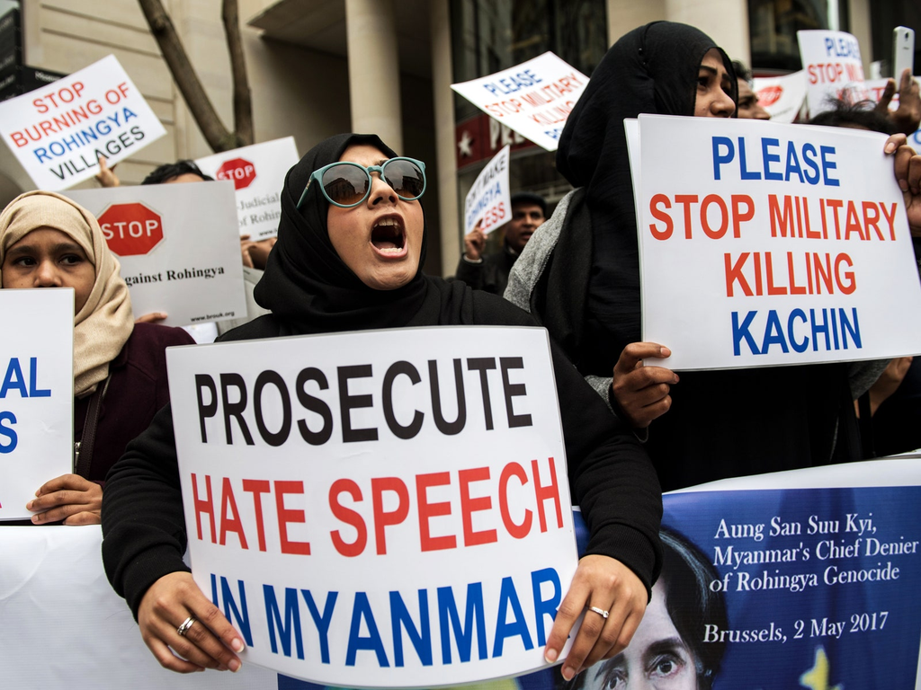

16. March 17: Hate speech. **Dr. Alexandra Siegel**. Assistant Professor of Political Science, University of Colorado at Boulder. Nonresident fellow at Brookings.
    - **Required Readings/listening**:
      - Online Hate Speech. 2020. Alexandra A. Siegel. *Social Media and Democracy*. (Required text)
      - [#No2Sectarianism: Experimental Approaches to Reducing Sectarian Hate Speech Online](https://www.cambridge.org/core/journals/american-political-science-review/article/no2sectarianism-experimental-approaches-to-reducing-sectarian-hate-speech-online/27157485824C8E071CB2DD3E26012EA3). 2020. Alexandra A. Siegel and Vivienne Badaan. *American Political Science Review*.
      - [Social media companies block Trump, but where’s the bigger reckoning with hate speech?](https://www.marketplace.org/shows/marketplace-tech/social-media-companies-facebook-twitter-block-trump-but-wheres-the-bigger-reckoning-with-hate-speech/). Molly Wood. Marketplace. (Read or listen)
      - [Another Facebook worker quits in disgust, saying the company ‘is on the wrong side of history’](https://www.washingtonpost.com/technology/2020/09/08/facebook-employee-quit-racism/). 2020. Craig Timberg and Elizabeth Dwoskin. *Washington Post*.
    - **Going deeper**:
      - [(a) Curbing Hate Online: What Companies Should Do Now](https://www.americanprogress.org/issues/immigration/reports/2018/10/25/459668/curbing-hate-online-companies-now/). 2018. Henry Fernandez. Center for American Progress.
      - [(a) Intersectional Bias in Hate Speech and Abusive Language Datasets](https://arxiv.org/pdf/2005.05921.pdf). 2021. Jae Yeon Kim, Carlos Ortiz, Sarah Nam, Sarah Santiago, Vivek Datta. ICWSM 2020 Data Challenge Workshop.
      - [(b) Trumping Hate on Twitter? Online Hate Speech in the 2016 US Election Campaign and its Aftermath](https://alexandra-siegel.com/wp-content/uploads/2019/08/qjps_election_hatespeech_RR.pdf). 2021. Alexandra A. Siegel et al. *Quarterly Journal of Political Science*.
      - [(b) Measuring and Characterizing Hate Speech on News Websites](https://arxiv.org/pdf/2005.07926.pdf). 2020. Savvas Zannettou, Mai ElSherief, Elizabeth Belding, Shirin Nilizadeh, and Gianluca Stringhini. *WebSci’20*
      - [(c) Tweetment Effects on the Tweeted: Experimentally Reducing Racist Harassment](https://link.springer.com/article/10.1007/s11109-016-9373-5). 2016. Kevin Munger. *Political Behavior*.
      - [(c) Thou Shalt Not Hate: Countering Online Hate Speech](https://ojs.aaai.org//index.php/ICWSM/article/view/3237). 2019. Binny Mathew et al. Proceedings of the Thirteenth International AAAI Conference on Web and Social Media.

[figure not shown]

17. March 22: Censorship. **Dr. Jennifer Pan**. Assistant Professor, Department of Communication, Stanford University.
    - **Required Readings/listening**:
      - [How Censorship in China Allows Government Criticism but Silences Collective Expression](https://www.jstor.org/stable/43654017). 2013. Gary King, Jennifer Pan, and Margaret E. Roberts. 2013. *American Political Science Review*.
      - [How Saudi Crackdowns Fail to Silence Online Dissent](https://www.cambridge.org/core/services/aop-cambridge-core/content/view/1BA13DF8FD5D04EC181BCD4D1055254B/S0003055419000650a.pdf/how_saudi_crackdowns_fail_to_silence_online_dissent.pdf). 2020. Jennifer Pan and Alexandra A. Siegel. *American Political Science Review*.
      - [Chinese censorship invades the U.S. via WeChat](https://www.washingtonpost.com/technology/2021/01/07/wechat-censorship-china-us-ban/). 2021. Jeanne Whalen. *Washington Post*
      - [Pakistan’s new regulations aim to ‘silence the internet’](https://www.aljazeera.com/news/2020/12/2/pakistans-new-regulations-aim-to-silence-the). 2020. Asad Hashim. *Aljazeera*.
      - [Do Law Enforcement Bots Reduce Freedom of Expression Online?](https://citizensandtech.org/2020/09/chilling-effect-automated-law-enforcemen/). 2020. J. Nathan Matias, Jonathon Penney, Merry Ember Mou, and Max Klein. CATLab.
    - **Going deeper**:
      - [(a) Censored: Distraction and Diversion Inside China’s Great Firewall](https://press.princeton.edu/books/hardcover/9780691178868/censored). 2018. Margaret E. Roberts. (Read chapters 2 & 7 )
      - [(b) Censored: Distraction and Diversion Inside China’s Great Firewall](https://press.princeton.edu/books/hardcover/9780691178868/censored). 2018. Margaret E. Roberts. (Read chapters 3-5)

[figure not shown]

18. March 24: The law and social media. **Prof. Lisa Hoppenjans**. Assistant Professor of Practice and Director, First Amendment Clinic, School of Law, Washington University in St. Louis.
    - **Required Readings/listening**:
      - [Knight First Amendment Institute v. Trump](https://en.wikipedia.org/wiki/Knight_First_Amendment_Institute_v._Trump). Wikipedia.
      - [*Knight First Amendment Institute, et al v. Donald J. Trump, et al*](https://knightcolumbia.org/documents/a07ecc2a26/2019.07.09_ECF-141-1_Opinion.pdf). Decision.
      - [Hello! You’ve Been Referred Here Because You’re Wrong About Section 230 Of The Communications Decency Act](https://www.techdirt.com/articles/20200531/23325444617/hello-youve-been-referred-here-%20%20because-youre-wrong-about-section-230-communications-decency-act.shtml). 2020. Mike Masnick. *TechDirty*.
      - Dealing with Disinformation: Evaluating the Case for Amendment of Section 230 of the Communications Decency Act. 2020. Tim Hwang. *Social Media and Democracy*. (Required text)
      - [GOP Sen. Hawley unveils his latest attack on tech’s liability shield in new bill](https://www.cnbc.com/2020/06/17/gop-sen-hawley-unveils-latest-attack-on-techs-liability-shield.html). 2020. Lauren Feiner. CNBC.
    - **Going deeper**:
      - [Why the Government Should Not Regulate Content Moderation of Social Media](https://www.cato.org/publications/policy-analysis/why-government-should-not-regulate-content-moderation-social-media). 2019. John Samples. Cato Institute.
      - [Online content moderation lessons from outside the US](https://www.brookings.edu/blog/techtank/2020/06/17/online-content-moderation-lessons-from-outside-the-u-s/). 2020. David Morar and Bruna Martins dos Santos. Brookings.
      - [Facebook while black: Users call it getting ‘Zucked,’ say talking about racism is censored as hate speech](https://www.usatoday.com/story/news/2019/04/24/facebook-while-black-zucked-users-say-they-get-blocked-racism-discussion/2859593002/). 2019. Jessica Guynn. *USA Today*.
      - [The Rioters Who Took Over The Capitol Have Been Planning Online In The Open For Weeks](https://www.buzzfeednews.com/article/janelytvynenko/trump-rioters-planned-online?utm_source=digg). 2021. Jane Lytvynenko and Molly Hensley-Clancy. *Buzz Feed News*.

[figure not shown]

19. March 29: Elite-driven misinformation and propaganda.
    - **Required Readings/listening**:
      - Misinformation, Disinformation, and Online Propoganda. 2020. Andrew M. Guess and Benjamin A. Lyons. *Social Media and Democracy*. (Required text)
      - [The Effects of Unsubstantiated Claims of Voter Fraud on Confidence in Elections](https://www.dartmouth.edu/~nyhan/voter-fraud.pdf). 2021. Nicolas Berlinski, Margaret Doyle, Andrew M. Guess, Gabrielle Levy, Benjamin Lyons, Jacob M. Montgomery, and Jason Reifler
      - [Voter Fraud Is Rare, but Myth Is Widespread](https://www.nytimes.com/2014/06/11/upshot/vote-fraud-is-rare-but-myth-is-widespread.html). 2014. Brendan Nyhan. *New York Times*.
      - [“Flood the zone with shit”: How misinformation overwhelmed our democracy](https://www.vox.com/policy-and-politics/2020/1/16/20991816/impeachment-trial-trump-bannon-misinformation). 2020. Sean Illing. Vox.com.
    - **Going deeper**:
      - (a) How the Chinese Government Fabricates Social Media Posts for Strategic Distraction, Not Engaged Argument. 2017. Gary King, Jennifer Pan, and Margaret E. Roberts. *American Political Science Review*.
      - (a) Elites Tweet to Get Feet Off the Streets: Measuring Regime Social Media Strategies During Protest. 2018. Kevin Munger, Richard Bonneau, Jonathan Nagler, and Joshua A. Tucker.
      - [(b) Under the sun](https://www.youtube.com/watch?v=uDl207dCyRE). (Documentary)

[video not shown]

20. March 31: Network information loss. **Dr. Taylor Carlson**, Assistant Professor, Department of Political Science, Washington University in St. Louis
    - **Required Readings/listening**:
      - [What to Believe? Social Media Commentary and Belief in Misinformation](https://link.springer.com/article/10.1007/s11109-018-9515-z). 2020. Nicolas M. Anspach and Taylor N. Carlson. *Political Behavior*.
      - [Through the Grapevine: Informational Consequences of Interpersonal Political Communication](https://www.cambridge.org/core/journals/american-political-science-review/article/through-the-grapevine-informational-consequences-of-interpersonal-political-communication/6CBBDCAD4AF791DA8C446F9B502FDD90). 2019. Taylor N. Carlson. *American Political Science Review*.
      - [Rumors, confusion, and conspiracies: Can doctors defeat COVID-19 misinformation?](https://www.aamc.org/news-insights/rumors-confusion-and-conspiracies-can-doctors-defeat-covid-19-misinformation). 2020. Association of American Medical Colleges (AAMC).
      - [TikTok Is Becoming a Vector of Election Violence Rumors](https://www.rollingstone.com/culture/culture-news/tiktok-2020-election-violence-threats-rumors-1085379/). 2020. EJ Dickson. *Rolling Stone*.
    - **Going deeper**:
      - [Political Chameleons: An Exploration of Conformity in Political Discussions](https://link.springer.com/article/10.1007/s11109-016-9335-y). 2016. Taylor N. Carlson and Jaime E. Settle. *Political Behavior*.
      - [Opting Out of Political Discussions](https://www.tandfonline.com/doi/full/10.1080/10584609.2018.1561563). 2019. Jaime E. Settle and Taylor N. Carlson.

[figure not shown]

21. April 5: Algorithms
    - **Required Readings/listening**:
      - [TikTok Teens and K-Pop Stans Say They Sank Trump Rally](https://www.nytimes.com/2020/06/21/style/tiktok-trump-rally-tulsa.html). 2020. Taylor Lorenz, Kellen Browning and Sheera Frenkel. *New York Times*
      - [#TulsaFlop: A Case Study of Algorithmically-Influenced Collective Action on TikTok](https://arxiv.org/abs/2012.07716). 2020. Jack Bandy and Nicholas Diakopoulos.
      - [Sorting the News: How Ranking by Popularity Polarizes Our Politics](https://www.tandfonline.com/doi/full/10.1080/10584609.2020.1713267). 2020. Yotam Shmargad and Samara Klar. *Political Communication*.
      - [End the Algorithm](https://techpolicy.press/end-the-algorithm/). 2020. EJ Fagan. *Tech Policy Press*.
    - **Going deeper**:
      - [(a) The Trust Engineers](https://www.wnycstudios.org/podcasts/radiolab/articles/trust-engineers). Radiolab (Podcast)
      - (a) The Distorting Prism of Social Media How Self-Selection and Exposure to Incivility Fuel Online Comment Toxicity. Andrew Guess, Jin Woo Kim, Brendan Nyhan, and Jason Reifler. (Canvas)
      - [(b) Perceived Popularity and Online Political Dissent: Evidence from Twitter in Venezuela](https://journals.sagepub.com/doi/abs/10.1177/1940161219872942?journalCode=hijb). 2020. Juan S. Morales. *The International Journal of Press/Politics*.
      - [(b) The New Personal Influence: How Our Facebook Friends Influence the News We Read](https://www.tandfonline.com/doi/full/10.1080/10584609.2017.1316329). 2017. Nicolas M. Anspach. *Political Communication*.

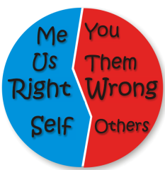

22. April 7: Identity and the origins of misperceptions
    - **Required Readings/listening**:
      - [The Partisan Brain: An Identity-Based Model of Political Belief](https://www.sciencedirect.com/science/article/pii/S1364661318300172). 2018. Jay J. Van Bavel and Andrea Pereira. *Trends in Cognitive Sciences*.
      - [Partisanship, Health Behavior, and Policy Attitudes in the Early Stages of the COVID-19 Pandemic](https://papers.ssrn.com/sol3/papers.cfm?abstract_id=3562796). 2020. Shana Kushner Gadarian, Sara Wallace Goodman, and Thomas B. Pepinsky.
      - [Why More Democrats Are Now Embracing Conspiracy Theories](https://www.nytimes.com/2017/02/15/upshot/why-more-democrats-are-now-embracing-conspiracy-theories.html). 2017. Brendan Nyhan. *New York Times*.
      - [Partisan pandemic: How partisanship and public health concerns affect individuals’ social mobility during COVID-19](https://advances.sciencemag.org/content/7/2/eabd7204.abstract). 2020. J. Clinton, J. Cohen, J. Lapinskiand M. Trussler. *Science Advances*.
    - **Going deeper**:
      - [(a) The Genesis of the Birther Rumor: Partisanship, Racial Attitudes, and Political Knowledge](https://www.cambridge.org/core/journals/journal-of-race-ethnicity-and-politics/article/genesis-of-the-birther-rumor-partisanship-racial-attitudes-and-political-knowledge/8C13EDF7D45A475E97B5D2B35BC8979E). 2018. Ashley Jardina and Michael Traugott. *Journal of Race, Ethnicity, and Politics*.
      - (a) Are All ‘Birthers’ Conspiracy Theorists? On the Relationship Between Conspiratorial Thinking and Political Orientations. 2020. Adam M. Enders, Steven M. Smallpage, and Robert Lupton. *British Journal of Political Science*.
      - [(b) Conspiracy and Misperception Belief in the Middle East and North Africa](https://www.journals.uchicago.edu/doi/full/10.1086/698663). 2018. Brendan Nyhan and Thomas Zeitzoff. *Journal of Politics*.
      - [(b) Fighting the Past: Perceptions of Control, Historical Misperceptions, and Corrective Information in the Israeli-Palestinian Conflict](https://onlinelibrary.wiley.com/doi/epdf/10.1111/pops.12449). 2018. Brendan Nyhan and Thomas Zeitzoff. *Political Psychology*

[figure not shown]

23. April 12: Wellness day

[figure not shown]

24. April 14: Motivated reasoning. **Dr. Calvin Lai**. Assistant Professor of Psychological & Brain Sciences, Washington University in St. Louis
    - **Required Readings/listening**:
      - [The Nature and Origins of Misperceptions: Understanding False and Unsupported Beliefs About Politics](https://onlinelibrary.wiley.com/doi/full/10.1111/pops.12394). 2017. DJ Flynn, Brendan Nyhan, and Jason Reifler. *Political Psychology*.
      - [The Selective Communication of Political Information](https://psyarxiv.com/pnr9u/). 2020. Pierce D. Ekstrom and Calvin K. Lai. *Social Psychological and Personality Science*.
      - [Lazy, not biased: Susceptibility to partisan fake news is better explained by lack of reasoning than by motivated reasoning](https://www.sciencedirect.com/science/article/pii/S001002771830163X). 2019. Gordon Pennycook and David G.Rand. *Cognition*.
    - **Going Deeper**:
      - [(a) Conspiracy Endorsement as Motivated Reasoning: The Moderating Roles of Political Knowledge and Trust](https://onlinelibrary.wiley.com/doi/full/10.1111/ajps.12234). 2016. Joanne M. Miller, Kyle L. Saunders, Christina E. Farhart. *American Journal of Political Science*.
      - (a) Political Knowledge and Misinformation in the Era of Social Media: Evidence From the 2015 UK Election. 2020. Kevin Munger, Patrick J. Egan, Jonathan Nagler, Jonathan Ronen, and Joshua Tucker. *British Journal of Political Science*.
      - [(b) Ideological Asymmetries and the Determinants of Politically Motivated Reasoning](https://www.brianguay.com/files/GuayJohnston_2020_AJPS.pdf). 2021. Brian Guay and Christopher Johnston. *American Journal of Political Science*.
      - [(b) Is the Political Right More Credulous?: Experimental Evidence Against Asymmetric Motivations to Believe False Political Information](http://timryan.web.unc.edu/files/2020/07/Ryan-Aziz-Asymmetric-Credulity.pdf). 2021. Timothy J. Ryan and Amanda Aziz.

[figure not shown]

25. April 19: What can we do?
    - **Required Readings/listening**:
      - [Preventing harassment and increasing group participation through social norms in 2,190 online science discussions](https://natematias.com/media/JNM-Preventing-Harassment-PNAS-2019.pdf). 2019. J. Nathan Matias. *Proceedings of the National Academy of Sciences*.
      - [A digital media literacy intervention increases discernment between mainstream and false news in the United States and India](https://www.pnas.org/content/117/27/15536). 2020. Andrew M. Guess, VMichael Lerner, Benjamin Lyons, Jacob M. Montgomery, Brendan Nyhan, Jason Reifler, and Neelanjan Sircar. *Proceedings of the National Academy of Sciences*.
      - [Shifting attention to accuracy can reduce misinformation online](https://psyarxiv.com/3n9u8/). 2021. Gordon Pennycook, Ziv Epstein, Mohsen Mosleh, Antonio A. Arechar, Dean Eckles, and David G. Rand.
    - **Going Deeper**:
      - [(a) Fake Claims of Fake News: Political Misinformation, Warnings, and the Tainted Truth Effect](https://link.springer.com/content/pdf/10.1007/s11109-020-09597-3.pdf). 2020. Melanie Freeze, Mary Baumgartner, Peter Bruno, Jacob R. Gunderson, Joshua Olin, Morgan Quinn Ross, Justine Szafran. *Political Behavior*.
      - [(a) Real Solutions for Fake News? Measuring the Effectiveness of General Warnings and Fact-Check Tags in Reducing Belief in False Stories on Social Media](https://link.springer.com/article/10.1007/s11109-019-09533-0?fbclid=IwAR3A6FCJXnpKCklBoZIIso_emB-mlBe65z_jm_N2NN3Gclrjz5oi9GXDhIU&error=cookies_not_supported&code=54e4f61f-200c-4b79-9941-d325027e46a6). 2019. Katherine Clayton et al. *Political Behavior*
      - [(b) Fighting misinformation on social media using crowdsourced judgments of news source quality](https://www.pnas.org/content/116/7/2521.short). 2019. Gordon Pennycook and David G. Rand. *Proceedings of the National Academy of Sciences*.
      - [(b) Distortions of political bias in crowdsourced misinformation flagging](https://www.ncbi.nlm.nih.gov/pmc/articles/PMC7328405/). 2020. Michele Coscia and Luca Rossi. *Journal of the Royal Society Interface*.
      - [(c) Boomerang Effects in Science Communication: How Motivated Reasoning and Identity Cues Amplify Opinion Polarization About Climate Mitigation Policies](https://journals.sagepub.com/doi/pdf/10.1177/0093650211416646). 2012. P. Sol Hart and Erik C. Nisbet. *Communcation Research*.
      - (c) Does Counter-Attitudinal Information Cause Backlash? Results from Three Large Survey Experiments. 2020. Andrew Guess and Alexander Coppock. *British Journal of Political Science*.

[figure not shown]

[figure not shown]

27. April 26: New frontiers of disinformation. **Dr. Chrisopher Lucas**. Assistant Professor, Political Science, Washington University in St. Louis.
    - **Required Readings/watching**:
      - Watch: [Moon disaster](https://moondisaster.org/film)
      - [Deepfakes 101](https://moondisaster.org/deepfakes-101). Moondisaster.org
      - [Deepfake Dystopia](https://moondisaster.org/deepfake-dystopia). Moondisaster.org
      - [Media Literacy in the Age of Disinformation](https://moondisaster.org/media-literacy-in-the-age-of-disinformation). Moondisaster.org
      - Political Deepfake Videos Misinform the Public, But No More than Other Fake Media. 2020. Soubhik Barari, Christopher Lucas, Kevin Munger. (Canvas)
      - All the News That’s Fit to Fabricate: AI-Generated Text as a Tool of Media Misinformation. 2020. Sarah Kreps, R. Miles McCain, Miles Brundage. *Journal of Experimental Political Science*.

[figure not shown]

28. April 28: Democracy without facts? **Brendan Nyhan**. Professor, Department of Government, Dartmouth College.
    - **Required Readings/listening**:
      - [Making Sense of the Facebook Menace: Can the largest media platform in the world ever be made safe for democracy?](https://newrepublic.com/article/160661/facebook-menace-making-platform-safe-democracy). 2021. Siva Vaidhyanathan. *The New Republic*.
      - [Facts and Myths about Misperceptions](https://www.aeaweb.org/articles?id=10.1257/jep.34.3.220). 2020. Brendan Nyhan. *Journal of Economic Perspectives*.
      - [How The 2020 Election Has Changed Trust In U.S. Democrac](https://www.npr.org/2020/11/15/935112333/how-the-2020-election-has-changed-trust-in-u-s-democracy). 2020. NPR. (Listen)
      - [Stigler Committee on Digital Platforms (pgs 6-22)](https://www.chicagobooth.edu/-/media/research/stigler/pdfs/digital-platforms---committee-report---stigler-center.pdf)

[figure not shown]

29. May 3. Select class presentations.
[^1]: Note that there is one day between Monday and Wednesday and more days between Wednesday and Monday. However, the same amount of reading is expected for each class session. You may, therefore, want to space out your reading to account for that. Just saying.
[^2]: My thanks to Brendan Nyhan for these references.
[^3]: You don’t have to write about the theme I identified. But if you are stuck, let me know and I’ll tell you what I was thinking.
[^4]: Don’t leave this till the last day. DM me in advance so we can brainstorm something if you are struggling.
[^5]: Your essay could explain how the strategies we discussed didn’t work in your case and discuss why that might have happend.